# Comparison of different-sized cities using the number of Starbucks stores and coffee shops

## Description of Problem and Background

From the FourSquare API, we are able to `query` different `venue categories` and `venue names` when we want to search for all nearby venues for a given (latitude, longitude) location. However, since we are only able to query up to `100` nearby venues using the free edition of the API, I want to find a defining `venue` to unqiuely identify and encompass some of the key characteristics of a given neighbourhood of a particular city. As a heavy coffee drinker myself, one of the first idea that came to mind is perhaps compare the frequency of the number of Starbucks stores as some sort of metric to idenity a neighbourhood. However, since the number of stores is going to vary greatly from city to city (depending on the city size, population, and the individuals' coffee preference), it would be more sensible to `normalize` this frequency by taking the ratio of the `number of Starbucks stores` to `total number of all other coffee stores`.

The hypothesis is that "similar" neighbourds from different cities could be clustered together using this `Starbucks store ratio`, i.e., Toronto and New York should have a more similar `Starbucks store ratio`, compared to Toronto and Vaughan (a smaller city in Ontario), given their city sizes, population density, cost of living etc.

## Description of the Data

First, we will use the FourSquare API to get a list of all the nearby venues of "coffee shops" for each city. This can be achieved by adding a `query` parameter when making the API call (i.e., `query = "coffee shop"`). Then, we will get a count of all nearby Starbucks store and also a count of all other nearby coffee stores for a given city (region). This can be done by applying a `one-hot encoder` (i.e., `1` for Starbucks and `0` for other coffee shops).

## Methodology

### Data Exploration using Toronto as an example

First, we will use the city of Toronto as an example to perform some exploratory analysis.

```python
#import libraries
import pandas as pd
import numpy as np
# pip install wikipedia
import wikipedia as wiki
pd.set_option('display.max_columns', None)
pd.set_option('display.max_rows', None)

import json # library to handle JSON files
from geopy.geocoders import Nominatim # convert an address into latitude and longitude values
import requests # library to handle requests
from pandas.io.json import json_normalize # tranform JSON file into a pandas dataframe
# Matplotlib and associated plotting modules
import matplotlib.cm as cm
import matplotlib.colors as colors

# import k-means from clustering stage
from sklearn.cluster import KMeans

#!conda install -c conda-forge folium=0.5.0 --yes # uncomment this line if you haven't completed the Foursquare API lab
import folium # map rendering library

print('Libraries imported.')
```

```
Libraries imported.
```

We will now use the wikipedia page of postal codes in Canada to get a list of all postal codes in Canada to get the longitude and latitudes of each Borough. Notice that we did this here because FourSquare API will limit each `location's` reulsts to a maximum of 100 venues for each given location of latitude and longtitude. In other words, if we simply use `Toronto` in the API call, we will only have a maximum of 100 nearby venues for the given latitude and longtitude of Toronto. However, if we break down the city into different Boroughs, then use each individual Borough as a unique API for latitude and longtitude, we can obtain a maximum of 100 nearby venues for each Borough.

```python
html = wiki.page("List_of_postal_codes_of_Canada:_M").html().encode("UTF-8")
df = pd.read_html(html)[0] #index 0 for first table

#exclude Borough that is "Not assigned"
df = df.loc[df["Borough"]!="Not assigned"]
print(df.shape)

#Using Google Maps Geocoding API to get Geospatial_Coordinates.csv
coord_df = pd.read_csv("Geospatial_Coordinates.csv")

df_coord = df.merge(coord_df, on="Postal Code", how="inner")
neighborhoods = df_coord.loc[df_coord["Borough"].str.contains("Toronto")]
```

```
(103, 3)
```

```python
#Four Square authetication
CLIENT_ID = 'EONBRWPKGBUQVGAJ1K50WNHNR3GX4QLLWHL330JJ52LYSF2N' # your Foursquare ID
CLIENT_SECRET = 'MH3OXWDNUPLJT3DZUSXCUB2Z0ANFDBDY5YIT3AHXK4YMYC2A' # your Foursquare Secret
VERSION = '20180605' # Foursquare API version
LIMIT = 100 # A default Foursquare API limit value

print('Your credentails:')
print('CLIENT_ID: ' + CLIENT_ID)
print('CLIENT_SECRET:' + CLIENT_SECRET)
```

```
Your credentails:
CLIENT_ID: EONBRWPKGBUQVGAJ1K50WNHNR3GX4QLLWHL330JJ52LYSF2N
CLIENT_SECRET:MH3OXWDNUPLJT3DZUSXCUB2Z0ANFDBDY5YIT3AHXK4YMYC2A
```

Implement a function that extracts the category of all nearby venues with radius 500, using `query = "coffee shop"`.

```python
# define a function that extracts the category of all nearby venues with radius 500
def getNearbyVenues(names, latitudes, longitudes, radius=500):
    venues_list=[]
    for name, lat, lng in zip(names, latitudes, longitudes):
        print(name)
        query = "coffee shop"
        # create the API request URL
        url = 'https://api.foursquare.com/v2/venues/explore?&client_id={}&client_secret={}&v={}&ll={},{}&radius={}&limit={}&query={}'.format(
            CLIENT_ID,
            CLIENT_SECRET,
            VERSION,
            lat,
            lng,
            radius,
            LIMIT,
            query)
        # make the GET request
        results = requests.get(url).json()["response"]['groups'][0]['items']
        # return only relevant information for each nearby venue
        venues_list.append([(
            name,
            lat,
            lng,
            v['venue']['name'],
            v['venue']['location']['lat'],
            v['venue']['location']['lng'],
            v['venue']['categories'][0]['name']) for v in results])
    nearby_venues = pd.DataFrame([item for venue_list in venues_list for item in venue_list])
    nearby_venues.columns = ['Neighborhood',
                  'Neighborhood Latitude',
                  'Neighborhood Longitude',
                  'Venue',
                  'Venue Latitude',
                  'Venue Longitude',
                  'Venue Category']

    return(nearby_venues)
```

```python
toronto_venues = getNearbyVenues(names=neighborhoods['Neighbourhood'],
                                   latitudes=neighborhoods['Latitude'],
                                   longitudes=neighborhoods['Longitude'])
```

```
Regent Park, Harbourfront
Queen's Park, Ontario Provincial Government
Garden District, Ryerson
St. James Town
The Beaches
Berczy Park
Central Bay Street
Christie
Richmond, Adelaide, King
Dufferin, Dovercourt Village
Harbourfront East, Union Station, Toronto Islands
Little Portugal, Trinity
The Danforth West, Riverdale
Toronto Dominion Centre, Design Exchange
Brockton, Parkdale Village, Exhibition Place
India Bazaar, The Beaches West
Commerce Court, Victoria Hotel
Studio District
Lawrence Park
Roselawn
Davisville North
Forest Hill North & West, Forest Hill Road Park
High Park, The Junction South
North Toronto West, Lawrence Park
The Annex, North Midtown, Yorkville
Parkdale, Roncesvalles
Davisville
University of Toronto, Harbord
Runnymede, Swansea
Moore Park, Summerhill East
Kensington Market, Chinatown, Grange Park
Summerhill West, Rathnelly, South Hill, Forest Hill SE, Deer Park
CN Tower, King and Spadina, Railway Lands, Harbourfront West, Bathurst Quay, South Niagara, Island airport
Rosedale
Stn A PO Boxes
St. James Town, Cabbagetown
First Canadian Place, Underground city
Church and Wellesley
Business reply mail Processing Centre, South Central Letter Processing Plant Toronto
```

```python
toronto_venues.head()
```

[output not shown]

```python
address = 'Toronto, ON'
geolocator = Nominatim(user_agent="toronto_explorer")
location = geolocator.geocode(address)
latitude = location.latitude
longitude = location.longitude
print('The geograpical coordinate of Toronto City are {}, {}.'.format(latitude, longitude))
```

```
The geograpical coordinate of Toronto City are 43.6534817, -79.3839347.
```

We will generate 2 random colors to be displayed on the map, one color would be the Starbucks store, and the other color would represent the other coffee stores.

```python
x = np.arange(2)
ys = [i + x + (i*x)**2 for i in range(2)]
colors_array = cm.rainbow(np.linspace(0, 1, len(ys)))
rainbow = [colors.rgb2hex(i) for i in colors_array]
rainbow
```

```
['#8000ff', '#ff0000']
```

```python
def fill_color(venue_name):
    if venue_name == "Starbucks":
        return rainbow[0]
    else:
        return rainbow[1]
```

Create a map where purple color represents a Starbucks store and red for all other coffee shops.

```python
map_clusters = folium.Map(location=[latitude, longitude], zoom_start=11)
# add markers to the map
markers_colors = []
for lat, lon, venue_name in zip(toronto_venues['Venue Latitude'], toronto_venues['Venue Longitude'], toronto_venues['Venue']):
    label = folium.Popup(str(venue_name) , parse_html=True)
    folium.CircleMarker(
        [lat, lon],
        radius=5,
        popup=label,
        fill=True,
        color=fill_color(venue_name),
        fill_color = fill_color(venue_name),
        fill_opacity=0.7).add_to(map_clusters)

map_clusters
```

Make this Notebook Trusted to load map: File -> Trust Notebook

[interactive chart not shown]

Generate a one-hot encoding using 1 for Starbucks and 0 for other coffee shops.

```python
toronto_venues["Starbucks_bool"] = toronto_venues["Venue"].apply(lambda x: 1 if x == "Starbucks" else 0)
toronto_venues.head()
```

|  | Neighborhood | Neighborhood Latitude | Neighborhood Longitude | Venue | Venue Latitude | Venue Longitude | Venue Category | Starbucks_bool |
| --- | --- | --- | --- | --- | --- | --- | --- | --- |
| 0 | Regent Park, Harbourfront | 43.65426 | -79.360636 | Tandem Coffee | 43.653559 | -79.361809 | Coffee Shop | 0 |
| 1 | Regent Park, Harbourfront | 43.65426 | -79.360636 | Sumach Espresso | 43.658135 | -79.359515 | Coffee Shop | 0 |
| 2 | Regent Park, Harbourfront | 43.65426 | -79.360636 | Arvo | 43.649963 | -79.361442 | Coffee Shop | 0 |
| 3 | Regent Park, Harbourfront | 43.65426 | -79.360636 | Rooster Coffee | 43.651900 | -79.365609 | Coffee Shop | 0 |
| 4 | Regent Park, Harbourfront | 43.65426 | -79.360636 | Starbucks | 43.651613 | -79.364917 | Coffee Shop | 1 |

Get a sample proportion of Starbucks to other coffee shops.

```python
toronto_venues["Starbucks_bool"].value_counts()[1]/toronto_venues["Starbucks_bool"].value_counts()[0]
```

```
0.20694645441389292
```

### Some potential problems and suggested fix

We are able to obtain a final ratio of Starbucks to non-Starbucks coffee shops to be about 20%. However, this method of mapping each borough to their corresponding latitudes and longtitude using the wikipedia page for each city isn't scalable. Hence, I have decided to just take the first 100 nearby venues whenever we call the FourSquare API on a given city name. This should also be representative for the entire city. We will also create a function that takes in a `city name` and returns `number of Starbucks store` and `number of other coffee stores`.

```python
def starbucks_ratio(city):
#     city = 'Toronto, Canada'
    geolocator = Nominatim(user_agent="toronto_explorer")
    location = geolocator.geocode(city)
    latitude = location.latitude
    longitude = location.longitude
    print('The geograpical coordinate of {} are {}, {}.'.format(city, latitude, longitude))
    radius=500
    LIMIT=100
    query= "coffee shop"
    # create the API request URL
    url = 'https://api.foursquare.com/v2/venues/explore?&client_id={}&client_secret={}&v={}&ll={},{}&radius={}&limit={}&query={}'.format(
        CLIENT_ID,
        CLIENT_SECRET,
        VERSION,
        latitude,
        longitude,
        radius,
        LIMIT,
        query)
    # make the GET request
    results = requests.get(url).json()["response"]['groups'][0]['items']
    if results:
        venues_list=[]
        venues_list.append([(
            v['venue']['name'],
            v['venue']['location']['lat'],
            v['venue']['location']['lng'],
            v['venue']['categories'][0]['name']) for v in results])
        nearby_venues = pd.DataFrame([item for venue_list in venues_list for item in venue_list])
        nearby_venues.columns = ['Venue', "Venue Latitude","Venue Longitude", "Venue Category"]
        nearby_venues

        nearby_venues["Starbucks_bool"] = nearby_venues["Venue"].apply(lambda x: 1 if "Starbucks" in x else 0)
        num_all_stores = len(nearby_venues["Starbucks_bool"])
        starbucks_freq = len(nearby_venues.loc[nearby_venues["Starbucks_bool"] == 1])/num_all_stores
        num_starbucks = len(nearby_venues.loc[nearby_venues["Starbucks_bool"] == 1])
        num_others = len(nearby_venues.loc[nearby_venues["Starbucks_bool"] == 0])
    else:
        starbucks_freq = 0
    print(f"ratio of Starbucks to other coffee shops: {starbucks_freq}, num_starbucks: {num_starbucks}, num_others: {num_others}")
    return num_starbucks, num_others
```

```python
starbucks_ratio("Toronto, Canada")
```

[output not shown]

```
(13, 57)
```

```python
print('The geograpical coordinate of {} are {}, {}.'.format(city, latitude, longitude))
# create map
map_clusters = folium.Map(location=[latitude, longitude], zoom_start=11)

# set color scheme for the clusters
# x = np.arange(kclusters)
# ys = [i + x + (i*x)**2 for i in range(kclusters)]
# colors_array = cm.rainbow(np.linspace(0, 1, len(ys)))
# rainbow = [colors.rgb2hex(i) for i in colors_array]

# add markers to the map
markers_colors = []
for lat, lon, venue_name in zip(nearby_venues['Venue Latitude'], nearby_venues['Venue Longitude'], nearby_venues['Venue']):
    label = folium.Popup(str(venue_name) , parse_html=True)
    folium.CircleMarker(
        [lat, lon],
        radius=5,
        popup=label,
        fill=True,
        color=fill_color(venue_name),
        fill_color = fill_color(venue_name),
        fill_opacity=0.7).add_to(map_clusters)

map_clusters
```

```
The geograpical coordinate of Toronto, Canada are 43.6534817, -79.3839347.
```

Make this Notebook Trusted to load map: File -> Trust Notebook

[interactive chart not shown]

# Results

Now, we will finally explore and create a scatter plot using different-sized cities in Ontario, Canada, hoping to find some clustering relationship between the city-size (in terms of population) and the Starbucks to other coffee shops ratio.

```python
cities = [
    #largest cities in Ontario by population size
    "Ottawa, Ontario", "Mississauga, Ontario", "Brampton, Ontario", "Hamilton, Ontario", "London, Ontario", "Markham, Ontario",

    #smallest cities in Ontario by population size
    "Dryden, Ontario", "Temiskaming Shores, Ontario", "Pembroke, Ontario", "Kenora, Ontario", "Port Colborne, Ontario", "Thorold, Ontario"
     ]
num_starbucks_lst = []
num_others_lst = []
for city in cities:
    num_starbucks, num_others = starbucks_ratio(city)
    num_starbucks_lst.append(num_starbucks)
    num_others_lst.append(num_others)
```

```
The geograpical coordinate of Ottawa, Ontario are 45.421106, -75.690308.
ratio of Starbucks to other coffee shops: 0.24, num_starbucks: 6, num_others: 19
The geograpical coordinate of Mississauga, Ontario are 43.5896231, -79.6443879.
ratio of Starbucks to other coffee shops: 0.23076923076923078, num_starbucks: 3, num_others: 10
The geograpical coordinate of Brampton, Ontario are 43.6858146, -79.7599337.
ratio of Starbucks to other coffee shops: 0.16666666666666666, num_starbucks: 1, num_others: 5
The geograpical coordinate of Hamilton, Ontario are 43.2560802, -79.8728583.
ratio of Starbucks to other coffee shops: 0.10526315789473684, num_starbucks: 2, num_others: 17
The geograpical coordinate of London, Ontario are 42.9836747, -81.2496068.
ratio of Starbucks to other coffee shops: 0.08333333333333333, num_starbucks: 1, num_others: 11
The geograpical coordinate of Markham, Ontario are 43.8563707, -79.3376825.
ratio of Starbucks to other coffee shops: 0.0, num_starbucks: 0, num_others: 6
The geograpical coordinate of Dryden, Ontario are 49.785698, -92.835846.
ratio of Starbucks to other coffee shops: 0.5, num_starbucks: 1, num_others: 1
The geograpical coordinate of Temiskaming Shores, Ontario are 47.508731, -79.6789029.
ratio of Starbucks to other coffee shops: 0.0, num_starbucks: 0, num_others: 1
The geograpical coordinate of Pembroke, Ontario are 45.8260909, -77.113541.
ratio of Starbucks to other coffee shops: 0.0, num_starbucks: 0, num_others: 4
The geograpical coordinate of Kenora, Ontario are 49.766215, -94.4893528.
ratio of Starbucks to other coffee shops: 0.16666666666666666, num_starbucks: 1, num_others: 5
The geograpical coordinate of Port Colborne, Ontario are 42.8862392, -79.2513905.
ratio of Starbucks to other coffee shops: 0.0, num_starbucks: 0, num_others: 1
The geograpical coordinate of Thorold, Ontario are 43.1249127, -79.2005935.
ratio of Starbucks to other coffee shops: 0.0, num_starbucks: 0, num_others: 4
```

We will now plot the result using a scatter plot with each city as the labels.

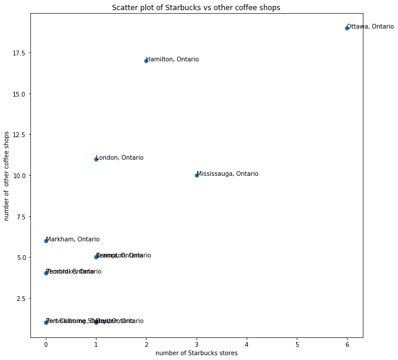

```python
import matplotlib.pyplot as plt
fig, ax = plt.subplots()
ax.scatter(num_starbucks_lst, num_others_lst)

for i, city_name in enumerate(cities):
    ax.annotate(city_name, (num_starbucks_lst[i], num_others_lst[i]))
plt.xlabel("number of Starbucks stores")
plt.ylabel("number of  other coffee shops")
plt.title("Scatter plot of Starbucks vs other coffee shops")
plt.gcf().set_size_inches((10, 10))
plt.show()
```

# Discussion

Now, we will apply a `kmeans clustering` algorithm, with number of clusters equal to `2`, hoping to cluster/label each cities using their Starbucks to other coffee shops ratio.

```python
k_means = KMeans(init="k-means++", n_clusters=2, n_init=12)
X = np.column_stack((num_starbucks_lst, num_others_lst))
k_means.fit(X)
y_kmeans = k_means.predict(X)
```

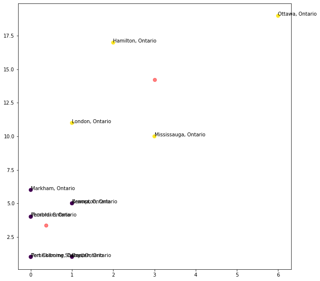

```python
plt.scatter(X[:, 0], X[:, 1], c=y_kmeans, s=50, cmap='viridis')
centers = k_means.cluster_centers_
plt.scatter(centers[:, 0], centers[:, 1], c='red', s=50, alpha=0.5)
for i, city_name in enumerate(cities):
    plt.annotate(city_name, (num_starbucks_lst[i], num_others_lst[i]))
plt.gcf().set_size_inches((10, 10))
```

Finally, we can see that the kmeans algorithm, have more or less clustered the cities based on the population, with the `yellow` labeled colors being cities with large populations, and `purple` being the smaller sized cities. The `red` dots represents the two centroid for the two clusters.

# Discussion

Now that we have observed a potential relationship between city-size and their Starbucks ratio, we will now experiment by adding some other cities from all over the world (not just limited to Ontario). These cities will have different population sizes as well (i.e., they are not sorted in terms of population size).

```python
cities = [
#     added major ciites in the world
    "Toronto", "New York City", "Tokyo", "Taipei", "Istanbul", "Moscow", "Paris", "London", "Madrid", "Berlin", "Delhi",

    #largest cities in Ontario by population size
    "Ottawa, Ontario", "Mississauga, Ontario", "Brampton, Ontario", "Hamilton, Ontario", "London, Ontario", "Markham, Ontario",

    #smallest cities in Ontario by population size
    "Dryden, Ontario", "Temiskaming Shores, Ontario", "Pembroke, Ontario", "Kenora, Ontario", "Port Colborne, Ontario", "Thorold, Ontario"
     ]
num_starbucks_lst = []
num_others_lst = []
for city in cities:
    num_starbucks, num_others = starbucks_ratio(city)
    num_starbucks_lst.append(num_starbucks)
    num_others_lst.append(num_others)
```

```
The geograpical coordinate of Toronto are 43.6534817, -79.3839347.
ratio of Starbucks to other coffee shops: 0.18571428571428572, num_starbucks: 13, num_others: 57
The geograpical coordinate of New York City are 40.7127281, -74.0060152.
ratio of Starbucks to other coffee shops: 0.15, num_starbucks: 6, num_others: 34
The geograpical coordinate of Tokyo are 35.6828387, 139.7594549.
ratio of Starbucks to other coffee shops: 0.1, num_starbucks: 3, num_others: 27
The geograpical coordinate of Taipei are 25.0375198, 121.5636796.
ratio of Starbucks to other coffee shops: 0.1, num_starbucks: 7, num_others: 63
The geograpical coordinate of Istanbul are 41.0096334, 28.9651646.
ratio of Starbucks to other coffee shops: 0.012345679012345678, num_starbucks: 1, num_others: 80
The geograpical coordinate of Moscow are 55.7504461, 37.6174943.
ratio of Starbucks to other coffee shops: 0.0, num_starbucks: 0, num_others: 3
The geograpical coordinate of Paris are 48.8566969, 2.3514616.
ratio of Starbucks to other coffee shops: 0.1, num_starbucks: 4, num_others: 36
The geograpical coordinate of London are 51.5073219, -0.1276474.
ratio of Starbucks to other coffee shops: 0.017543859649122806, num_starbucks: 1, num_others: 56
The geograpical coordinate of Madrid are 40.4167047, -3.7035825.
ratio of Starbucks to other coffee shops: 0.07042253521126761, num_starbucks: 5, num_others: 66
The geograpical coordinate of Berlin are 52.5170365, 13.3888599.
ratio of Starbucks to other coffee shops: 0.04, num_starbucks: 1, num_others: 24
The geograpical coordinate of Delhi are 28.6517178, 77.2219388.
ratio of Starbucks to other coffee shops: 0.0, num_starbucks: 0, num_others: 1
The geograpical coordinate of Ottawa, Ontario are 45.421106, -75.690308.
ratio of Starbucks to other coffee shops: 0.24, num_starbucks: 6, num_others: 19
The geograpical coordinate of Mississauga, Ontario are 43.5896231, -79.6443879.
ratio of Starbucks to other coffee shops: 0.23076923076923078, num_starbucks: 3, num_others: 10
The geograpical coordinate of Brampton, Ontario are 43.6858146, -79.7599337.
ratio of Starbucks to other coffee shops: 0.16666666666666666, num_starbucks: 1, num_others: 5
The geograpical coordinate of Hamilton, Ontario are 43.2560802, -79.8728583.
ratio of Starbucks to other coffee shops: 0.10526315789473684, num_starbucks: 2, num_others: 17
The geograpical coordinate of London, Ontario are 42.9836747, -81.2496068.
ratio of Starbucks to other coffee shops: 0.08333333333333333, num_starbucks: 1, num_others: 11
The geograpical coordinate of Markham, Ontario are 43.8563707, -79.3376825.
ratio of Starbucks to other coffee shops: 0.0, num_starbucks: 0, num_others: 6
The geograpical coordinate of Dryden, Ontario are 49.785698, -92.835846.
ratio of Starbucks to other coffee shops: 0.5, num_starbucks: 1, num_others: 1
The geograpical coordinate of Temiskaming Shores, Ontario are 47.508731, -79.6789029.
ratio of Starbucks to other coffee shops: 0.0, num_starbucks: 0, num_others: 1
The geograpical coordinate of Pembroke, Ontario are 45.8260909, -77.113541.
ratio of Starbucks to other coffee shops: 0.0, num_starbucks: 0, num_others: 4
The geograpical coordinate of Kenora, Ontario are 49.766215, -94.4893528.
ratio of Starbucks to other coffee shops: 0.16666666666666666, num_starbucks: 1, num_others: 5
The geograpical coordinate of Port Colborne, Ontario are 42.8862392, -79.2513905.
ratio of Starbucks to other coffee shops: 0.0, num_starbucks: 0, num_others: 1
The geograpical coordinate of Thorold, Ontario are 43.1249127, -79.2005935.
ratio of Starbucks to other coffee shops: 0.0, num_starbucks: 0, num_others: 4
```

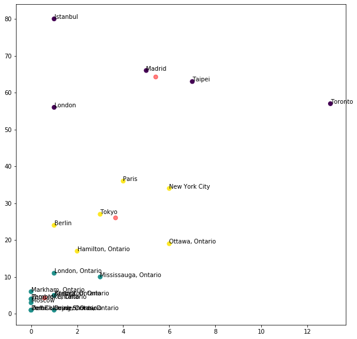

```python
k_means = KMeans(init="k-means++", n_clusters=3, n_init=12)
X = np.column_stack((num_starbucks_lst, num_others_lst))
k_means.fit(X)
y_kmeans = k_means.predict(X)
plt.scatter(X[:, 0], X[:, 1], c=y_kmeans, s=50, cmap='viridis')
centers = k_means.cluster_centers_
plt.scatter(centers[:, 0], centers[:, 1], c='red', s=50, alpha=0.5)
for i, city_name in enumerate(cities):
    plt.annotate(city_name, (num_starbucks_lst[i], num_others_lst[i]))
plt.gcf().set_size_inches((10, 10))
```

# Conclusion

This could be due to various geo-politcal and cultural reasons (and not just limited to population size/density), such as whether or not the people in these cities are less passionate about drinking coffee, or maybe there other pre-dominant chain coffee baristas other than Starbucks (i.e., perhaps people in New York or Paris are more likely to support local baristas), or simply due to the overall Starbucks company policy at different cities/regions.

Overall, we can conclude that there is indeed some relationship between a city's population and its "Starbucks to other coffee shops" ratio, but other factors might need to be considered as well. Hence, some recommended follow up could be adding other geo-politcal/cultural features to our clustering algorithm rather than just population density, such as "cost of living", etc.